# Activity: Bird Species

Madeline Mucciolo

June 7 2023

# Set Up

```r
# Load `tidyverse` and `dcData` packages
library(tidyverse)
library(dcData)

# Load the `OrdwayBirds` data set into your RStudio environment from the `dcData` package
data('OrdwayBirds', package = 'dcData')

# Show a few commands used to inspect the data set a few different ways
summary(OrdwayBirds)
```

```
    bogus            Timestamp             Year               Day               Month           CaptureTime        SpeciesName
 Length:15829       Length:15829       Length:15829       Length:15829       Length:15829       Length:15829       Length:15829
 Class :character   Class :character   Class :character   Class :character   Class :character   Class :character   Class :character
 Mode  :character   Mode  :character   Mode  :character   Mode  :character   Mode  :character   Mode  :character   Mode  :character
     Sex                Age             BandNumber           TrapID            Weather          BandingReport      RecaptureYN
 Length:15829       Length:15829       Length:15829       Length:15829       Length:15829       Length:15829       Length:15829
 Class :character   Class :character   Class :character   Class :character   Class :character   Class :character   Class :character
 Mode  :character   Mode  :character   Mode  :character   Mode  :character   Mode  :character   Mode  :character   Mode  :character
 RecaptureMonth     RecaptureDay        Condition           Release            Comments         DataEntryPerson       Weight
 Length:15829       Length:15829       Length:15829       Length:15829       Length:15829       Length:15829       Length:15829
 Class :character   Class :character   Class :character   Class :character   Class :character   Class :character   Class :character
 Mode  :character   Mode  :character   Mode  :character   Mode  :character   Mode  :character   Mode  :character   Mode  :character
  WingChord         Temperature        RecaptureOriginal  RecapturePrevious   TailLength
 Length:15829       Length:15829       Length:15829       Length:15829       Length:15829
 Class :character   Class :character   Class :character   Class :character   Class :character
 Mode  :character   Mode  :character   Mode  :character   Mode  :character   Mode  :character
```

```r
head(OrdwayBirds)
```

|  | bogus | Timestamp | Year | Day | Month | CaptureTime | SpeciesName | Sex | Age | BandNumber | TrapID | Weather | BandingReport | RecaptureYN | RecaptureMonth | RecaptureDay | Condition | Release | Comments | DataEntryPerson | Weight | WingChord | Temperature | RecaptureOriginal | RecapturePrevious | TailLength |
| --- | --- | --- | --- | --- | --- | --- | --- | --- | --- | --- | --- | --- | --- | --- | --- | --- | --- | --- | --- | --- | --- | --- | --- | --- | --- | --- |
| 3 | . | 4/14/2010 13:20:56 | 1972 | 16 | 7 | 7:00:00 | Song Sparrow | U | AHY (After Hatch Year) | 107-151187 | warbler | none | check mark in record | no check | none | none | none | none | none | Jerald Dosch |  |  |  |  |  |  |
| 4 | . |  |  |  |  |  |  |  |  |  |  |  |  |  |  |  |  |  |  | Caitlin Baker |  |  |  |  |  |  |
| 5 | . | 5/13/2010 16:00:30 | 1972 | 16 | 7 | 7:00:00 | Song Sparrow | U | AHY (After Hatch Year) | 107-151187 | Warbler | none | check mark in record | no check | none | none | none | none | none | Caitlin Baker |  |  |  |  |  |  |
| 6 | . | 5/13/2010 16:02:15 | 1972 | 16 | 7 | 7:00:00 | Field Sparrow | U | AHY (After Hatch Year) | 1260-74572 | Warbler | none | no check mark in record | check or yes | 7 | 9 | none | none | none | Caitlin Baker |  |  |  |  |  |  |
| 7 | . | 5/13/2010 16:03:18 | 1972 | 16 | 7 | 7:00:00 | Field Sparrow | U | AHY (After Hatch Year) | 1260-74541 | Elevator | none | no check mark in record | check or yes | 4 | 25 | none | none | none | Caitlin Baker |  |  |  |  |  |  |
| 8 | . | 5/13/2010 16:04:23 | 1972 | 16 | 7 | 7:00:00 | Song Sparrow | U | AHY (After Hatch Year) | 107-151188 | Elevator | none | check mark in record | no check | none | none | none | none | none | Caitlin Baker |  |  |  |  |  |  |

```r
sample_n(OrdwayBirds, 10)
```

| bogus | Timestamp | Year | Day | Month | CaptureTime | SpeciesName | Sex | Age | BandNumber | TrapID | Weather | BandingReport | RecaptureYN | RecaptureMonth | RecaptureDay | Condition | Release | Comments | DataEntryPerson | Weight | WingChord | Temperature | RecaptureOriginal | RecapturePrevious | TailLength |
| --- | --- | --- | --- | --- | --- | --- | --- | --- | --- | --- | --- | --- | --- | --- | --- | --- | --- | --- | --- | --- | --- | --- | --- | --- | --- |
| . | 1/28/2011 16:04:42 | 1973 | 23 | 10 | 10:00:00 | Fox Sparrow | U | AHY (After Hatch Year) | 791-02681 | Net G2 | Clear; calm | check mark in record | no check | none | none | none | none | none | Keith Bradley-Hewitt | 33.2 |  |  |  |  |  |
| . | 11/10/2010 17:09:38 | 1979 | 27 | 2 | 6:30:00 | Tree Sparrow | U | AHY (After Hatch Year) | 1460-64715 | M/2 | Slightly cloudy; calm | check mark in record | no check | none | none | none | none | none | Keith Bradley-Hewitt | 17.3 | 71 |  |  |  |  |
| . | 2/9/2011 18:30:44 | 1975 | 9 | 9 | 11:30:00 | Chipping Sparrow | U | AHY (After Hatch Year) | 1340-33700 | Net EL | Clear; moderate winds | check mark in record | no check | none | none | none | none | #560 | Keith Bradley-Hewitt | 12.1 | 70 |  |  |  |  |
| . | 9/20/2010 16:47:43 | 1972 | 8 | 5 | 6:00:00 | Field Sparrow | F | AHY (After Hatch Year) | 1260-74540 | funnel | none | no check mark in record | no check | none | none | none | none | none | Brennan Panzarella |  |  |  |  |  |  |
| . | 4/25/2011 20:00:19 | 1981 | 27 | 7 | 17:00:00 | Yellowthroat | F | HY (Hatch Year) | 1530-55311 | E | Cloudy; calm | check mark in record | no check | none | none | none | none | Yellow gape | Keith Bradley-Hewitt | 10.9 | 53 |  |  |  | 46 |
| . | 3/25/2011 15:04:37 | 1976 | 23 | 11 | 12:00:00 | Black-capped Chickadee | U | U (Unknown) | 1360-65430 | 2' MW | Cloudy; snow flurries; light winds | no check mark in record | check or yes | none | none | none | none | none | Keith Bradley-Hewitt | 11.5 |  |  |  |  |  |
| . | 3/7/2012 16:50:23 | 1983 | 25 | 5 | 10:00:00 | Yellowthroat | F | AHY (After Hatch Year) | 1620-64199 | G/ nest | clear; calm | check mark in record | no check | none | none | none | none | none | Mary Catherine Muñiz | 10.3 | 53 |  |  |  | 42 |
| . | 10/13/2010 16:42:02 | 1978 | 26 | 5 | 15:00:00 | Robin | U | L (Local) | 842-18299 | M nest/elm | Clear; calm | check mark in record | no check | none | none | none | none | none | Keith Bradley-Hewitt |  |  |  |  |  |  |
| . | 2/9/2011 16:20:01 | 1975 | 13 | 7 | 18:00:00 | Lincoln's Sparrow | F | AHY (After Hatch Year) | 840-34005 | Net GN | Cloudy; calm | no check mark in record | check or yes | none | none | none | Released | Released | Keith Bradley-Hewitt |  |  |  |  |  |  |
| . | 2/1/2011 10:42:21 | 1973 | 29 | 10 | 15:00:00 | Slate-colored Junco | M | HY (Hatch Year) | 1320-04405 | Net SE | Cloudy; calm | check mark in record | no check | none | none | none | none | none | Keith Bradley-Hewitt | 20.2 | 79 |  |  |  |  |

```r
nrow(OrdwayBirds)
```

```
[1] 15829
```

```r
?OrdwayBirds
```

- After briefly inspecting the data set, we see that there close to 16,000 cases and 26 variables for each. The data contains information about birds that were captured and released at the Katharine Ordway Natural History Study Area. The data contains variables describing the date and time they were captured (ex: ‘Day’, ‘Month’, ‘CaptureTime’), describing the birds (ex: ‘SpeciesName’, ‘Age’, ‘Sex’) and other variables about the capture (ex: ‘Weather’, ‘DataEntryPerson’).

# Activity

When you’re finished with this activity, you will have a graph that shows what time of year various species appear at the Katherine Ordway Natural History Study Area in Inver Grove Heights, MN.

### Step 0

Before we begin, the book gives us some instructions to select a few key variables and clean up the date formatting. Use the commands given in the book, but be sure to study the functions used so you know what is happening. In this case, we select `SpeciesName`, `Month`, and `Day`. Then a `mutate()` command converts each variable to character, and then converts the resulting “character string” to a number.

```r
# Get the data table & clean up dates (see Data Computing eBook)
OrdwayBirds <-
  OrdwayBirds %>%
  select( SpeciesName, Month, Day ) %>%
  mutate( Month = as.numeric(as.character(Month)),
          Day = as.numeric(as.character(Day)))

# Inspect resulting data
head(OrdwayBirds)
```

|  | SpeciesName | Month | Day |
| --- | --- | --- | --- |
| 3 | Song Sparrow | 7 | 16 |
| 4 |  | NA | NA |
| 5 | Song Sparrow | 7 | 16 |
| 6 | Field Sparrow | 7 | 16 |
| 7 | Field Sparrow | 7 | 16 |
| 8 | Song Sparrow | 7 | 16 |

```r
sample_n(OrdwayBirds, 10)
```

| SpeciesName | Month | Day |
| --- | --- | --- |
| Tree Swallow | 6 | 22 |
| White-Throated Sparrow | 5 | 10 |
| Blue Jay | 2 | 18 |
| Robin | 4 | 26 |
| Field Sparrow | 10 | 9 |
| Brown Thrasher | 5 | 8 |
| Tree Sparrow | 2 | 3 |
| Lincoln's Sparrow | 7 | 27 |
| Eastern Kingbird | 5 | 23 |
| American Goldfinch | 10 | 31 |

```r
nrow(OrdwayBirds)
```

```
[1] 15829
```

- After tidying the data into a more suitable form for our uses, the resulting table only has 3 columns (‘SpeciesName’, ‘Month’, ‘Day’) but still contains all of the original rows.

### Step 1

```r
# unique species in original data (including mis-spellings)
n_distinct(OrdwayBirds$SpeciesName)
```

```
[1] 275
```

```r
# unique species in the clean list
data('OrdwaySpeciesNames', package = 'dcData')
n_distinct(OrdwaySpeciesNames$SpeciesNameCleaned)
```

```
[1] 109
```

- In the species list with incorrect spellings, there were 275 different listed species. However, in the cleaned list, there were only 109 species.

### Step 2

```r
# inspect OrdwaySpeciesNames
summary(OrdwaySpeciesNames)
```

```
 SpeciesName        SpeciesNameCleaned
 Length:265         Length:265
 Class :character   Class :character
 Mode  :character   Mode  :character
```

```r
nrow(OrdwaySpeciesNames)
```

```
[1] 265
```

```r
head(OrdwaySpeciesNames)
```

|  | SpeciesName | SpeciesNameCleaned |
| --- | --- | --- |
| 1 |  | NA |
| 2 | -lost- | NA |
| 3 | -missing- | NA |
| 4 | [Nothing, just dashes] | NA |
| 5 | 13:00:00 | NA |
| 6 | Acadian Flycatcher | Acadian Flycatcher |

```r
# inner join
Corrected <-
  OrdwayBirds %>%
  inner_join( OrdwaySpeciesNames ) %>%
  select( Species = SpeciesNameCleaned, Month, Day ) %>%
  na.omit()  # cleaned up the missing ones
# inspect the data after the join
nrow(Corrected)
```

```
[1] 15144
```

```r
head(Corrected)
```

|  | Species | Month | Day |
| --- | --- | --- | --- |
| 1 | Song Sparrow | 7 | 16 |
| 3 | Song Sparrow | 7 | 16 |
| 4 | Field Sparrow | 7 | 16 |
| 5 | Field Sparrow | 7 | 16 |
| 6 | Field Sparrow | 7 | 16 |
| 7 | Field Sparrow | 7 | 16 |

```r
sample_n(Corrected, 10)
```

| Species | Month | Day |
| --- | --- | --- |
| Tree Swallow | 11 | 3 |
| Slate-colored Junco | 4 | 5 |
| Field Sparrow | 9 | 24 |
| White-breasted Nuthatch | 10 | 5 |
| Slate-colored Junco | 10 | 23 |
| Catbird | 7 | 1 |
| American Goldfinch | 5 | 17 |
| Orange-Crowned Warbler | 10 | 5 |
| Chipping Sparrow | 10 | 11 |
| Tree Swallow | 10 | 31 |

```r
n_distinct(Corrected$Species)
```

```
[1] 108
```

- After joining the two tables, the new Corrected table ensures that all species names are uniformly spelled. The variable SpeciesName was used to match cases and inner join the two tables. The variable that is added is a Species variable, which contains the corresponding SpeciesNameCleaned from the OrdwaySpeciesNames table.

### Step 3

We want to identify the top 5-6 bird species sighted at the Katherine Ordway Natural History Study Area.

```r
# count sightings by species in descending order
Corrected %>%
  group_by(Species) %>%
  summarise(count = n()) %>%
  arrange(desc(count)) %>%
  head(10) # a hint in the text book recommends displaying the top 10 species to choose our threshold
```

| Species | count |
| --- | --- |
| Slate-colored Junco | 2732 |
| Tree Swallow | 1537 |
| Black-capped Chickadee | 1327 |
| American Goldfinch | 1204 |
| Field Sparrow | 1164 |
| Lincoln's Sparrow | 790 |
| Robin | 608 |
| Catbird | 554 |
| Song Sparrow | 512 |
| House Wren | 460 |

```r
# define a sightings threshold; produce a table with only birds belonging to major species
Majors <-
  Corrected %>%
  group_by(Species) %>%
  summarise(count = n()) %>%
  filter(count > 1000)

head(Majors)
```

| Species | count |
| --- | --- |
| American Goldfinch | 1204 |
| Black-capped Chickadee | 1327 |
| Field Sparrow | 1164 |
| Slate-colored Junco | 2732 |
| Tree Swallow | 1537 |

- I began by finding the number of bird captures for each species. I arranged these numbers into descending order, and was able to locate the top ten most captures birds during the data collection. For my definition of a major species, it is any species with count over 1000.I used this definition to filter out species into the new Majors data.

### Step 4

We now want to produce a month-by-month count for each of the major species, and then construct a chart to tell the story of what time of year the various species appear.

```r
ByMonth <-
  Majors %>%
  left_join(Corrected) %>%
  select(Species, Month) %>%
  group_by(Species, Month) %>%
  summarise(Count_Per_month = n())
print(ByMonth)
```

| Species | Month | Count_Per_month |
| --- | --- | --- |
| American Goldfinch | 1 | 10 |
| American Goldfinch | 2 | 51 |
| American Goldfinch | 3 | 52 |
| American Goldfinch | 4 | 21 |
| American Goldfinch | 5 | 150 |
| American Goldfinch | 6 | 66 |
| American Goldfinch | 7 | 69 |
| American Goldfinch | 8 | 78 |
| American Goldfinch | 9 | 160 |
| American Goldfinch | 10 | 364 |

[output cut: 42 more lines]

- I created ByMonth, a table containing only the major species (as defined above) and the number of sightings for each per month. I had to use a join between the Majors table and the Corrected table.

Now use the ggplot template below to generate the desired graph. (Remark you can also use esquisser or mplot to create a line chart instead of the barchart)

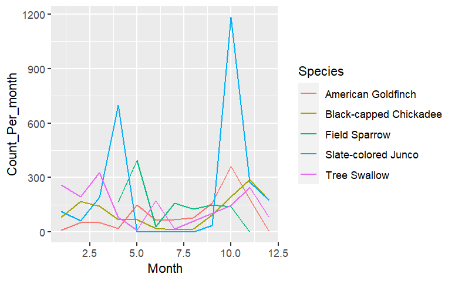

```r
# ggplot commands

ByMonth %>%
  ggplot(aes(x = Month, y = Count_Per_month, color = Species)) +
  geom_line()
```

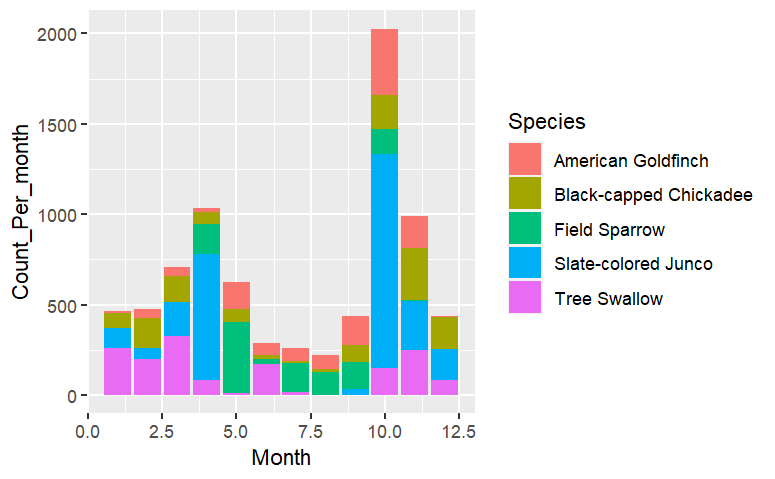

```r
ByMonth %>% ggplot(aes(x=Month,y=Count_Per_month ,fill=Species)) +
  geom_bar(stat='identity',position='stack', width=.9)
```

According to the graph, we can answer the questions posed:

##### 3. What is the peak month for each major species? (bullet list)

- The peak month for American Goldfinch is the 10th month (October). The peak month for Black-capped Chickadee is the 11th month (November). The peak month for Field Sparrow is the 5th month (May). The peak month for Slate-colored Juno is the 10th month (October). The peak month for Tree Swallow is the 3rd month (March).

##### 4. Which major species are seen in good numbers for at least 6 months of the year?

- All of the major species are seen in good numbers for at least 6 months of the year.